# Daten beschaffen

Jan-Philipp Kolb

11 Januar 2018

# [EU Initiative INSPIRE](http://inspire.ec.europa.eu/reports/Registration_form.pdf)

[figure not shown]

### Ziele:

- Räumliche Information zugänglicher und interoperabel machen
- Nachhaltige Entwicklung in diesem Bereich unterstützen

### Entwicklung

- Aufgrund der Richtlinie sind mehr Daten frei verfügbar.

# Zensus Atlas

Für den Zensus 2011 kann man Daten herunterladen und/oder diese in Karten visualisieren.

### https://ergebnisse.zensus2011.de/

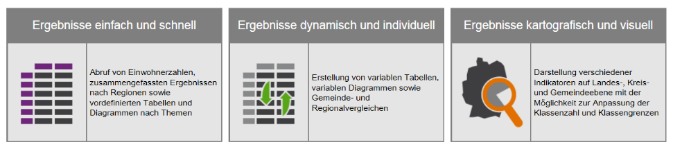

Zensus Datenbank

# [Zensus Gemeindeergebnisse](https://www.destatis.de/DE/Methoden/Zensus_/Zensus.html)

```r
setwd(zen_path)
bev_dat <- readxl::read_excel("xlsx_Bevoelkerung.xlsx",3)
DT::datatable(bev_dat[1:1000,1:20])
```

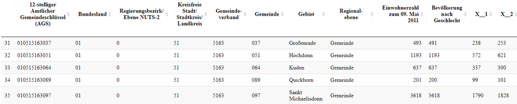

# A3A Aufgabe: Zensus Ergebnisse für Gemeinden downloaden

- Lade die Zensus Gemeinde Ergebnisse [**hier**](https://www.zensus2011.de/SharedDocs/Aktuelles/Ergebnisse/DemografischeGrunddaten.html) herunter.
- Importiere die Daten mit einer geeigneten Funktion in R.
- Welche Information ist in den Daten enthalten?

# [Der amtliche Gemeindeschlüssel](https://de.wikipedia.org/wiki/Amtlicher_Gemeindeschl%C3%BCssel)

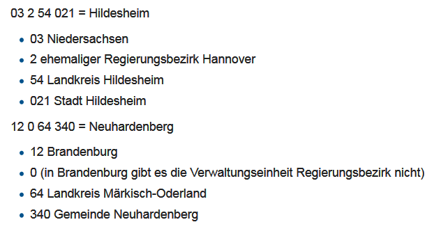

# AGS - Bundesländer

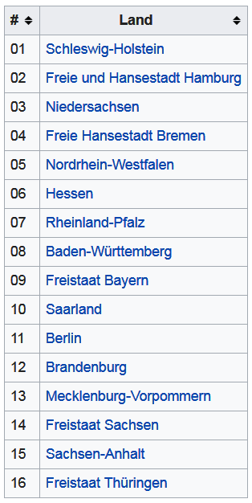

# A3B Aufgabe

- Nutze die Gemeindeergebnisse für den Zensus 2011 und erzeuge einen Datensatz, der nur die Ergebnisse für die Saarländischen Gemeinden enthält.
- Ermittle aus diesem Datensatz die Gemeinde in der der Anteil der unter 1-jährigen am höchsten ist.
- Speichere einen Datensatz ab, in dem die folgenden Variablen enthalten sind:
  - der amtliche Gemeindeschlüssel,
  - die Gemeindenamen,
  - die Bevölkerungszahl insgesamt
  - die Zahl der Einjährigen und
  - die Zahl der Zwanzigjährigen

# Forschungsdatenzentren

- Bspw. FDZ der statistischen Ämter:

http://www.forschungsdatenzentrum.de/

- Es werden hauptsächlich Public Use Files angeboten,
- Teilweise können Gewichtungsfaktoren verwendet werden um regionale Ergebnisse zu bekommen
- In der Regel ist Darstellung in Karten aber schwierig